# Case Study 1: How does a bike-share navigate speedy success?

Khalid MD Ashik

2022-11-30

##### This analysis is based on the Divvy case study “‘Sophisticated, Clear, and Polished’: Divvy and Data Visualization” written by Kevin Hartman (found here: https://artscience.blog/home/divvy-dataviz-case-study). The purpose of this script is to consolidate downloaded Divvy data into a single dataframe and then conduct simple analysis to help answer the key question: “In what ways do members and casual riders use Divvy bikes differently?”

#### In this case study, I have performed data analysis for a fictional bike-share company in order to help them attract more riders. Along the way, I performed numerous real-world tasks of a junior data analyst by following the steps of the data analysis process: Ask, Prepare, Process, Analyze, Share, and Act.

# # # # # # # # # # # # # # # # # # # # # #

#### Installed required packages

#### tidyverse for data import and wrangling

#### lubridate for date functions

# # # # # # # # # # # # # # # # # # # # # #

```r
install.packages("tidyverse", repos = "http://cran.us.r-project.org")
install.packages("lubridate", repos = "http://cran.us.r-project.org")
```

```r
install.packages("ggplot2", repos = "http://cran.us.r-project.org")
install.packages("dplyr", repos = "http://cran.us.r-project.org")
library(tidyverse)
library(lubridate)
library(ggplot2)
library(dplyr)
getwd()
```

```
## [1] "/Users/rising.volkan007/Desktop/q1_2020"
```

```r
setwd("/Users/rising.volkan007/Desktop/q1_2020")
```

### STEP 1: COLLECTED DATA

```r
q1_2022 <- read_csv("202210-divvy-tripdata.csv", show_col_types = FALSE)
q2_2022 <- read_csv("202209-divvy-tripdata.csv", show_col_types = FALSE)
q3_2022 <- read_csv("202208-divvy-tripdata.csv", show_col_types = FALSE)
q4_2022 <- read_csv("202207-divvy-tripdata.csv", show_col_types = FALSE)
q5_2022 <- read_csv("202206-divvy-tripdata.csv", show_col_types = FALSE)
q6_2022 <- read_csv("202205-divvy-tripdata.csv", show_col_types = FALSE)
q7_2022 <- read_csv("202204-divvy-tripdata.csv", show_col_types = FALSE)
q8_2022 <- read_csv("202203-divvy-tripdata.csv", show_col_types = FALSE)
q9_2022 <- read_csv("202201-divvy-tripdata.csv", show_col_types = FALSE)
```

### STEP 2: WRANGLE DATA AND COMBINE INTO A SINGLE FILE

#### Compared column names each of the files

#### While the names don’t have to be in the same order, they DO need to match perfectly before we can use a command to join them into one file

```r
colnames(q1_2022)
```

```
##  [1] "ride_id"            "rideable_type"      "started_at"
##  [4] "ended_at"           "start_station_name" "start_station_id"
##  [7] "end_station_name"   "end_station_id"     "start_lat"
## [10] "start_lng"          "end_lat"            "end_lng"
## [13] "member_casual"
```

```r
colnames(q2_2022)
```

```
##  [1] "ride_id"            "rideable_type"      "started_at"
##  [4] "ended_at"           "start_station_name" "start_station_id"
##  [7] "end_station_name"   "end_station_id"     "start_lat"
## [10] "start_lng"          "end_lat"            "end_lng"
## [13] "member_casual"
```

```r
colnames(q3_2022)
```

```
##  [1] "ride_id"            "rideable_type"      "started_at"
##  [4] "ended_at"           "start_station_name" "start_station_id"
##  [7] "end_station_name"   "end_station_id"     "start_lat"
## [10] "start_lng"          "end_lat"            "end_lng"
## [13] "member_casual"
```

```r
colnames(q4_2022)
```

```
##  [1] "ride_id"            "rideable_type"      "started_at"
##  [4] "ended_at"           "start_station_name" "start_station_id"
##  [7] "end_station_name"   "end_station_id"     "start_lat"
## [10] "start_lng"          "end_lat"            "end_lng"
## [13] "member_casual"
```

```r
colnames(q5_2022)
```

```
##  [1] "ride_id"            "rideable_type"      "started_at"
##  [4] "ended_at"           "start_station_name" "start_station_id"
##  [7] "end_station_name"   "end_station_id"     "start_lat"
## [10] "start_lng"          "end_lat"            "end_lng"
## [13] "member_casual"
```

```r
colnames(q6_2022)
```

```
##  [1] "ride_id"            "rideable_type"      "started_at"
##  [4] "ended_at"           "start_station_name" "start_station_id"
##  [7] "end_station_name"   "end_station_id"     "start_lat"
## [10] "start_lng"          "end_lat"            "end_lng"
## [13] "member_casual"
```

#### Inspected the dataframes and look for incongruencies

#### Converted ride_id and rideable_type to character so that they can stack correctly

```r
q1_2022 <- mutate(q1_2022, ride_id= as.character(ride_id), rideable_type=as.character(rideable_type))

q2_2022 <- mutate(q2_2022, ride_id= as.character(ride_id), rideable_type=as.character(rideable_type))

q3_2022 <- mutate(q3_2022, ride_id= as.character(ride_id), rideable_type=as.character(rideable_type))

q4_2022 <- mutate(q4_2022, ride_id= as.character(ride_id), rideable_type=as.character(rideable_type))

q5_2022 <- mutate(q5_2022, ride_id= as.character(ride_id), rideable_type=as.character(rideable_type))

q6_2022 <- mutate(q6_2022, ride_id= as.character(ride_id), rideable_type=as.character(rideable_type))

q7_2022 <- mutate(q7_2022, ride_id= as.character(ride_id), rideable_type=as.character(rideable_type))

q8_2022 <- mutate(q8_2022, ride_id= as.character(ride_id), rideable_type=as.character(rideable_type))

q9_2022 <- mutate(q9_2022, ride_id= as.character(ride_id), rideable_type=as.character(rideable_type))
```

```r
all_trips <- bind_rows(q1_2022, q2_2022, q3_2022, q4_2022,q5_2022,q6_2022,q7_2022,q8_2022,q9_2022)
```

#### Removed lat, long data was dropped beginning in 2022

```r
all_trips <- all_trips %>%
  select(-c(start_lat,start_lng,end_lat,end_lng))
```

### STEP 3: CLEAN UP AND ADD DATA TO PREPARE FOR ANALYSIS

#### Inspect the new table that has been created

```r
colnames(all_trips)  #List of column names
```

```
## [1] "ride_id"            "rideable_type"      "started_at"
## [4] "ended_at"           "start_station_name" "start_station_id"
## [7] "end_station_name"   "end_station_id"     "member_casual"
```

```r
nrow(all_trips)  #How many rows are in data frame?
```

```
## [1] 5032567
```

```r
dim(all_trips)  #Dimensions of the data frame?
```

```
## [1] 5032567       9
```

```r
head(all_trips)  #See the first 6 rows of data frame.  Also tail(all_trips)
```

```
## # A tibble: 6 × 9
##   ride_id        ridea…¹ started_at          ended_at            start…² start…³
##   <chr>          <chr>   <dttm>              <dttm>              <chr>   <chr>
## 1 A50255C1E1794… classi… 2022-10-14 17:13:30 2022-10-14 17:19:39 Noble … 13290
## 2 DB692A70BD2DD… electr… 2022-10-01 16:29:26 2022-10-01 16:49:06 Damen … 13288
## 3 3C02727AAF60F… electr… 2022-10-19 18:55:40 2022-10-19 19:03:30 Hoyne … 655
## 4 47E653FDC2D99… electr… 2022-10-31 07:52:36 2022-10-31 07:58:49 Rush S… KA1504…
## 5 8B5407BE53515… classi… 2022-10-13 18:41:03 2022-10-13 19:26:18 900 W … 13028
## 6 A177C92E9F021… electr… 2022-10-13 15:53:27 2022-10-13 15:59:17 900 W … 13028
## # … with 3 more variables: end_station_name <chr>, end_station_id <chr>,
## #   member_casual <chr>, and abbreviated variable names ¹rideable_type,
## #   ²start_station_name, ³start_station_id
```

```r
tail(all_trips)
```

```
## # A tibble: 6 × 9
##   ride_id        ridea…¹ started_at          ended_at            start…² start…³
##   <chr>          <chr>   <dttm>              <dttm>              <chr>   <chr>
## 1 9C80CD03B685B… electr… 2022-01-09 18:56:50 2022-01-09 19:02:50 Broadw… 13325
## 2 8788DA3EDE8FD… electr… 2022-01-18 12:36:48 2022-01-18 12:46:19 Clinto… WL-012
## 3 C6C3B64FDC827… electr… 2022-01-27 11:00:06 2022-01-27 11:02:40 Racine… 13155
## 4 CA281AE7D8B06… electr… 2022-01-10 16:14:51 2022-01-10 16:20:58 Broadw… 13325
## 5 44E3489918623… electr… 2022-01-19 13:22:11 2022-01-19 13:24:27 Racine… 13155
## 6 E477C594A182A… electr… 2022-01-13 17:24:43 2022-01-13 17:28:14 Clinto… WL-012
## # … with 3 more variables: end_station_name <chr>, end_station_id <chr>,
## #   member_casual <chr>, and abbreviated variable names ¹rideable_type,
## #   ²start_station_name, ³start_station_id
```

```r
str(all_trips)  #See list of columns and data types (numeric, character, etc)
```

```
## tibble [5,032,567 × 9] (S3: tbl_df/tbl/data.frame)
##  $ ride_id           : chr [1:5032567] "A50255C1E17942AB" "DB692A70BD2DD4E3" "3C02727AAF60F873" "47E653FDC2D99236" ...
##  $ rideable_type     : chr [1:5032567] "classic_bike" "electric_bike" "electric_bike" "electric_bike" ...
##  $ started_at        : POSIXct[1:5032567], format: "2022-10-14 17:13:30" "2022-10-01 16:29:26" ...
##  $ ended_at          : POSIXct[1:5032567], format: "2022-10-14 17:19:39" "2022-10-01 16:49:06" ...
##  $ start_station_name: chr [1:5032567] "Noble St & Milwaukee Ave" "Damen Ave & Charleston St" "Hoyne Ave & Balmoral Ave" "Rush St & Cedar St" ...
##  $ start_station_id  : chr [1:5032567] "13290" "13288" "655" "KA1504000133" ...
##  $ end_station_name  : chr [1:5032567] "Larrabee St & Division St" "Damen Ave & Cullerton St" "Western Ave & Leland Ave" "Orleans St & Chestnut St (NEXT Apts)" ...
##  $ end_station_id    : chr [1:5032567] "KA1504000079" "13089" "TA1307000140" "620" ...
##  $ member_casual     : chr [1:5032567] "member" "casual" "member" "member" ...
```

```r
summary(all_trips)  #Statistical summary of data. Mainly for numerics
```

```
##    ride_id          rideable_type        started_at
##  Length:5032567     Length:5032567     Min.   :2022-01-01 00:00:05.0
##  Class :character   Class :character   1st Qu.:2022-05-26 22:46:23.0
##  Mode  :character   Mode  :character   Median :2022-07-14 15:02:45.0
##                                        Mean   :2022-07-10 18:41:37.5
##                                        3rd Qu.:2022-09-01 07:25:58.5
##                                        Max.   :2022-10-31 23:59:33.0
##     ended_at                      start_station_name start_station_id
##  Min.   :2022-01-01 00:01:48.00   Length:5032567     Length:5032567
##  1st Qu.:2022-05-26 23:01:21.00   Class :character   Class :character
##  Median :2022-07-14 15:23:31.00   Mode  :character   Mode  :character
##  Mean   :2022-07-10 19:01:45.52
##  3rd Qu.:2022-09-01 07:39:32.00
##  Max.   :2022-11-07 04:53:58.00
##  end_station_name   end_station_id     member_casual
##  Length:5032567     Length:5032567     Length:5032567
##  Class :character   Class :character   Class :character
##  Mode  :character   Mode  :character   Mode  :character
##
##
##
```

#### Checked to make sure the proper number of observations were reassigned

```r
table(all_trips$member_casual)
```

```
##
##  casual  member
## 2154950 2877617
```

#### Added columns that list the date, month, day, and year of each ride

#### This will allow us to aggregate ride data for each month, day, or year … before completing these operations we could only aggregate at the ride level

#### https://www.statmethods.net/input/dates.html more on date formats in R found at that link

```r
all_trips$date <- as.Date(all_trips$started_at) #The default format is yyyy-mm-dd
all_trips$month <- format(as.Date(all_trips$date), "%m")
all_trips$day <- format(as.Date(all_trips$date), "%d")
all_trips$year <- format(as.Date(all_trips$date), "%Y")
all_trips$day_of_week <- format(as.Date(all_trips$date), "%A")
```

#### Added a “ride_length” calculation to all_trips (in seconds)

#### https://stat.ethz.ch/R-manual/R-devel/library/base/html/difftime.html

```r
all_trips$ride_length <- difftime(all_trips$ended_at,all_trips$started_at)
```

#### Inspect the structure of the columns

```r
str(all_trips)
```

```
## tibble [5,032,567 × 15] (S3: tbl_df/tbl/data.frame)
##  $ ride_id           : chr [1:5032567] "A50255C1E17942AB" "DB692A70BD2DD4E3" "3C02727AAF60F873" "47E653FDC2D99236" ...
##  $ rideable_type     : chr [1:5032567] "classic_bike" "electric_bike" "electric_bike" "electric_bike" ...
##  $ started_at        : POSIXct[1:5032567], format: "2022-10-14 17:13:30" "2022-10-01 16:29:26" ...
##  $ ended_at          : POSIXct[1:5032567], format: "2022-10-14 17:19:39" "2022-10-01 16:49:06" ...
##  $ start_station_name: chr [1:5032567] "Noble St & Milwaukee Ave" "Damen Ave & Charleston St" "Hoyne Ave & Balmoral Ave" "Rush St & Cedar St" ...
##  $ start_station_id  : chr [1:5032567] "13290" "13288" "655" "KA1504000133" ...
##  $ end_station_name  : chr [1:5032567] "Larrabee St & Division St" "Damen Ave & Cullerton St" "Western Ave & Leland Ave" "Orleans St & Chestnut St (NEXT Apts)" ...
##  $ end_station_id    : chr [1:5032567] "KA1504000079" "13089" "TA1307000140" "620" ...
##  $ member_casual     : chr [1:5032567] "member" "casual" "member" "member" ...
##  $ date              : Date[1:5032567], format: "2022-10-14" "2022-10-01" ...
##  $ month             : chr [1:5032567] "10" "10" "10" "10" ...
##  $ day               : chr [1:5032567] "14" "01" "19" "31" ...
##  $ year              : chr [1:5032567] "2022" "2022" "2022" "2022" ...
##  $ day_of_week       : chr [1:5032567] "Friday" "Saturday" "Wednesday" "Monday" ...
##  $ ride_length       : 'difftime' num [1:5032567] 369 1180 470 373 ...
##   ..- attr(*, "units")= chr "secs"
```

```r
all_trips$ride_length <- as.numeric(as.character(all_trips$ride_length))
is.numeric(all_trips$ride_length)
```

```
## [1] TRUE
```

#### We will create a new version of the dataframe (v2) since data is being removed

#### https://www.datasciencemadesimple.com/delete-or-drop-rows-in-r-with-conditions-2/

```r
all_trips_v2 <- all_trips[!(all_trips$start_station_name == "HQ QR" | all_trips$ride_length<0),]
```

### STEP 4: CONDUCT DESCRIPTIVE ANALYSIS

#### Descriptive analysis on ride_length (all figures in seconds)

```r
mean(all_trips_v2$ride_length) #straight average (total ride length / rides)
```

```
## [1] NA
```

```r
median(all_trips_v2$ride_length) #midpoint number in the ascending array of ride lengths
```

```
## [1] NA
```

```r
max(all_trips_v2$ride_length) #longest ride
```

```
## [1] NA
```

```r
min(all_trips_v2$ride_length) #shortest ride
```

```
## [1] NA
```

#### I had condensed the four lines above to one line using summary() on the specific attribute

```r
summary(all_trips_v2$ride_length)
```

```
##    Min. 1st Qu.  Median    Mean 3rd Qu.    Max.    NA's
##       0     371     653    1277    1176 2483235  733225
```

#### Compared members and casual users

```r
aggregate(all_trips_v2$ride_length ~ all_trips_v2$member_casual, FUN = mean)
```

```
##   all_trips_v2$member_casual all_trips_v2$ride_length
## 1                     casual                 1932.152
## 2                     member                  787.723
```

```r
aggregate(all_trips_v2$ride_length ~ all_trips_v2$member_casual, FUN = median)
```

```
##   all_trips_v2$member_casual all_trips_v2$ride_length
## 1                     casual                      837
## 2                     member                      551
```

```r
aggregate(all_trips_v2$ride_length ~ all_trips_v2$member_casual, FUN = max)
```

```
##   all_trips_v2$member_casual all_trips_v2$ride_length
## 1                     casual                  2483235
## 2                     member                    93594
```

```r
aggregate(all_trips_v2$ride_length ~ all_trips_v2$member_casual, FUN = min)
```

```
##   all_trips_v2$member_casual all_trips_v2$ride_length
## 1                     casual                        0
## 2                     member                        0
```

#### See the average ride time by each day for members vs casual users

```r
aggregate(all_trips_v2$ride_length ~ all_trips_v2$member_casual + all_trips_v2$day_of_week, FUN = mean)
```

```
##    all_trips_v2$member_casual all_trips_v2$day_of_week all_trips_v2$ride_length
## 1                      casual                   Friday                1863.6220
## 2                      member                   Friday                 770.7869
## 3                      casual                   Monday                1948.2110
## 4                      member                   Monday                 759.6822
## 5                      casual                 Saturday                2142.9944
## 6                      member                 Saturday                 883.3955
## 7                      casual                   Sunday                2219.5627
## 8                      member                   Sunday                 874.1955
## 9                      casual                 Thursday                1678.0602
## 10                     member                 Thursday                 756.6890
## 11                     casual                  Tuesday                1737.7837
## 12                     member                  Tuesday                 750.2949
## 13                     casual                Wednesday                1652.1514
## 14                     member                Wednesday                 747.5031
```

#### Notice that the days of the week are out of order. Let’s fix that

```r
all_trips_v2$day_of_week <- ordered(all_trips_v2$day_of_week, levels=c("Sunday", "Monday", "Tuesday", "Wednesday", "Thursday", "Friday", "Saturday"))
```

#### Now, let’s run the average ride time by each day for members vs casual users

```r
aggregate(all_trips_v2$ride_length ~ all_trips_v2$member_casual + all_trips_v2$day_of_week, FUN = mean)
```

```
##    all_trips_v2$member_casual all_trips_v2$day_of_week all_trips_v2$ride_length
## 1                      casual                   Sunday                2219.5627
## 2                      member                   Sunday                 874.1955
## 3                      casual                   Monday                1948.2110
## 4                      member                   Monday                 759.6822
## 5                      casual                  Tuesday                1737.7837
## 6                      member                  Tuesday                 750.2949
## 7                      casual                Wednesday                1652.1514
## 8                      member                Wednesday                 747.5031
## 9                      casual                 Thursday                1678.0602
## 10                     member                 Thursday                 756.6890
## 11                     casual                   Friday                1863.6220
## 12                     member                   Friday                 770.7869
## 13                     casual                 Saturday                2142.9944
## 14                     member                 Saturday                 883.3955
```

#### analyze ridership data by type and weekday

```r
all_trips_v2 %>%
  mutate(weekday = wday(started_at, label = TRUE)) %>%  #creates weekday field using wday()
  group_by(member_casual, weekday) %>%  #groups by usertype and weekday
  summarise(number_of_rides = n()                           #calculates the number of rides and average duration
  ,average_duration = mean(ride_length)) %>%        # calculates the average duration
  arrange(member_casual, weekday)
```

```
## # A tibble: 15 × 4
## # Groups:   member_casual [3]
##    member_casual weekday number_of_rides average_duration
##    <chr>         <ord>             <int>            <dbl>
##  1 casual        Sun              316093            2220.
##  2 casual        Mon              220388            1948.
##  3 casual        Tue              202664            1738.
##  4 casual        Wed              209858            1652.
##  5 casual        Thu              237255            1678.
##  6 casual        Fri              261776            1864.
##  7 casual        Sat              388860            2143.
##  8 member        Sun              289515             874.
##  9 member        Mon              348050             760.
## 10 member        Tue              375587             750.
## 11 member        Wed              381003             748.
## 12 member        Thu              389414             757.
## 13 member        Fri              344143             771.
## 14 member        Sat              334677             883.
## 15 <NA>          <NA>             733225              NA
```

#### Let’s visualize the number of rides by rider type

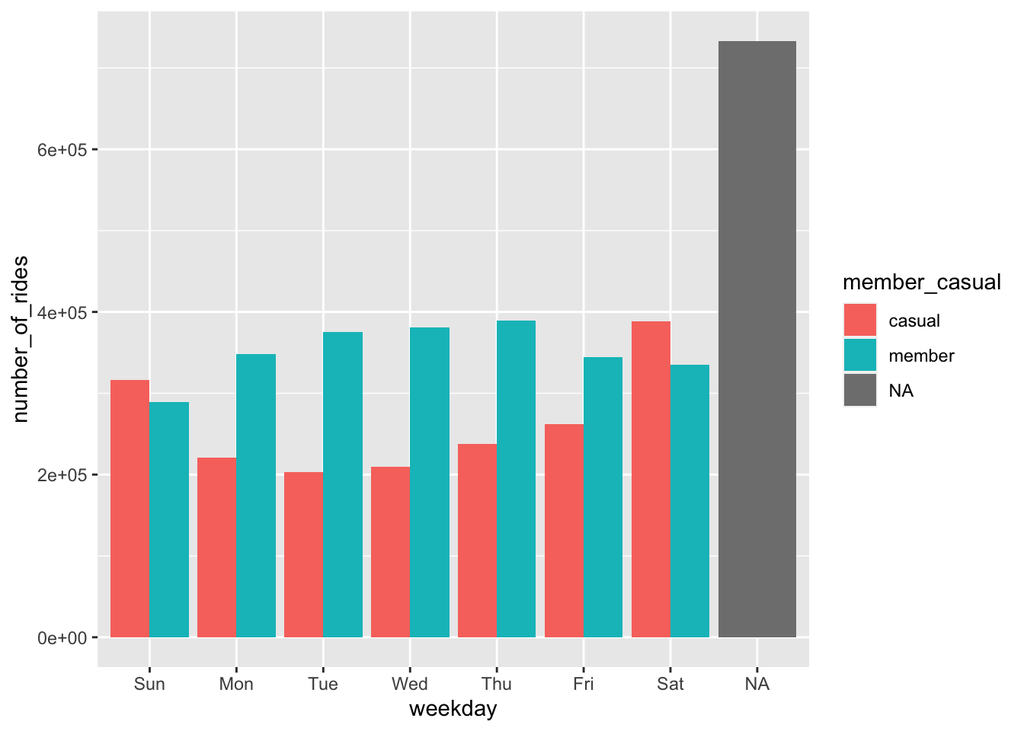

```r
all_trips_v2 %>%
  mutate(weekday = wday(started_at, label = TRUE)) %>%
  group_by(member_casual, weekday) %>%
  summarise(number_of_rides = n()
            ,average_duration = mean(ride_length)) %>%
  arrange(member_casual, weekday)  %>%
  ggplot(aes(x = weekday, y = number_of_rides, fill = member_casual)) +
  geom_col(position = "dodge")
```

#### Let’s create a visualization for average duration

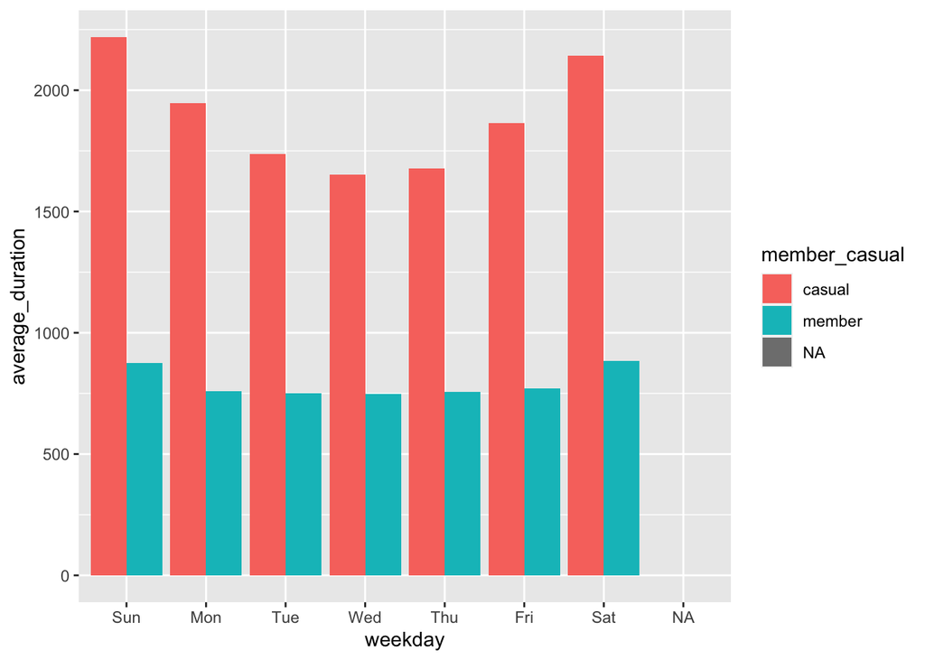

```r
all_trips_v2 %>%
  mutate(weekday = wday(started_at, label = TRUE)) %>%
  group_by(member_casual, weekday) %>%
  summarise(number_of_rides = n()
            ,average_duration = mean(ride_length)) %>%
  arrange(member_casual, weekday)  %>%
  ggplot(aes(x = weekday, y = average_duration, fill = member_casual)) +
  geom_col(position = "dodge")
```

### STEP 5: EXPORT SUMMARY FILE FOR FURTHER ANALYSIS

#### Created a csv file that we will visualize in Excel, Tableau, or my presentation software

##### N.B.: This file location is for a Mac. If you are working on a PC, change the file location accordingly (most likely “C:_USERNAME...”) to export the data. You can read more here: https://datatofish.com/export-dataframe-to-csv-in-r/

```r
counts <- aggregate(all_trips_v2$ride_length ~ all_trips_v2$member_casual + all_trips_v2$day_of_week, FUN = mean)
write.csv(counts, file = '~/Desktop/q1_2020/avg_ride_length.csv')
```